# The Effects of Selected Variables on ProsperRating

## by Opeyemi Rafiat Fasasi

## Investigation Overview

In this presentation, I wanted to find out the variables that can be used to predict the Prosper Rating of loans.The variables I would love to focus on are the LoanOriginalAmount, MonthlyLoanPayment and Term.

## Dataset Overview

This data set contains information about loans, including loan amount, borrower rate (or interest rate), current loan status, borrower income, and many others. The original dataset has 113937 rows and 81 columns. I reduced the number of rows to 84853, by selecting only loans that were originated after JUly 2009 and have a ProsperRating

## Distribution of LoanOriginalAmount

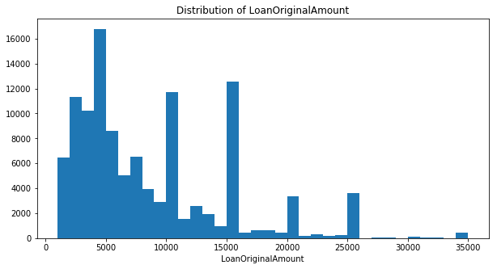

```python
bins =  np.arange(1000, df['LoanOriginalAmount'].max()+1000, 1000)
plt.figure(figsize=[10,5])
plt.hist(data = df, x = 'LoanOriginalAmount', bins = bins)
plt.title('Distribution of LoanOriginalAmount')
plt.xlabel('LoanOriginalAmount')
plt.show();
```

## Distribution of Terms across Ratings

This looks at the distribution of current loan terms across different Prosper Ratings. It was observed that for all Proper ratings, a term of 36 months was the most represented with rating 6 having the most volume at over 7000. The short term loans of 12 months were the least represented across all Prosper Ratings.

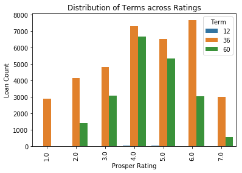

```python
df_current = df_09[df_09['LoanStatus'] == 'Current']
sb.countplot(data = df_current,x =  'ProsperRating (numeric)',  hue = 'Term' )
plt.xticks(rotation=90)
plt.title('Distribution of Terms across Ratings')
plt.xlabel('Prosper Rating')
plt.ylabel('Loan Count');
```

## Distribution of MonthlyLoanPayment Across ProsperRatings

It was observed that in general, the higher the prosper rating, the higher the monthly Payment. However, there was a small dip in monthly payment at Prosper Rating 6 but this quickly recovered and showed an upward trend at ProperRating 7.

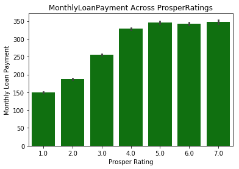

```python
sb.barplot(data=df, x='ProsperRating (numeric)', y='MonthlyLoanPayment', color = 'green')
plt.title('MonthlyLoanPayment Across ProsperRatings')
plt.xlabel('Prosper Rating')
plt.ylabel('Monthly Loan Payment');
```